# Children’s Health Around the World

Team Square

01/06/2021

#### **Team Members**:

- Aslı Kılıç - 090160303
- Yasemin Dikme - 090160313

## **Project Description**

#### Project Goal & Social Problem

Our goal is to study the health status of children around the world and to investigate the cause of poor health conditions. We want to raise awareness for children who need health services.

Children are among the most affected by the developments in the world today. Millions of children are deprived of their most basic human rights, due to many factors such as long years of wars, drought, the country’s economy etc.In our project, we will focus on the differences in children health across countries and its link with the development levels of countries.

We will take a look at some datasets that contains data from countries around the world and compare them with each other. By comparing we hope to find a pattern. By doing this, we want to show that there are children in need in some countries and how other countries should focus on helping this situation. Normal citizens know that children in some countries do not even have access to clean water, but more people should take an active role in this issue. We aim to show people the seriousness of the situation with the project we are trying to do. We want to create awareness with visual graphics so that people can understand them without being overwhelmed by data.

#### Project Data& Access to data

We aimed to find a reliable source for the project. We made sure that the datasets we use are suitable for use and ethical. That is why we used the datasets from the UNICEF and WHO (World Health Organization) dataset archives.

You can access our datasets from the official [UNICEF Data site](https://data.unicef.org/resources/resource-type/datasets/), [WHO Global Health Observatory data repository](https://apps.who.int/gho/data/node.main) and [The WHO/UNICEF Joint Monitoring Programme (JMP) dataset](https://washdata.org/data).

Additionally we used the [United Nations dataset](https://unstats.un.org/unsd/methodology/m49/) to determine geographic regions and [NASA World Map dataset](https://data.nasa.gov/dataset/World-Map/7zbq-j77a) for geospatial data.

The datasets we use contain data on different health problems faced by children. There are topics that we especially want to deal with.

## **Actions Taken**

We aimed to make our project understandable and easy to read. We used various graphics and maps for this. Instead of tiring the readers with numbers and complex data, we wanted to explain the data with colors and shapes.

First we loaded the packages we will use on our project. Then, in order to import our data, we checked the current working directory.

Since we wanted to show the data we obtained about the children from different countries on the map, we pulled the “world map” data set from NASA. Some of the countries were written differently on the world map dataset. We changed the names of misspelled countries to match the other datasets.

### Stillbirths

A baby who dies after 28 weeks of pregnancy, but before or during birth, is classified as a stillbirth [1].

According to our hypothesis, there is a relationship between the development levels of countries and the stillbirth rates of countries. To demonstrate this, we imported the dataset of UNICEF showing the stillbirth rate of the countries by years and the dataset showing the development levels of the countries. All of the datasets had different types of uncertainty bounds, such as lower, median and upper. According to UNICEF, lower and upper refer to the lower bound and upper bound of 90% uncertainty intervals. We will use the “Median Uncertainty Bound” or “Point Estimate” on our project.

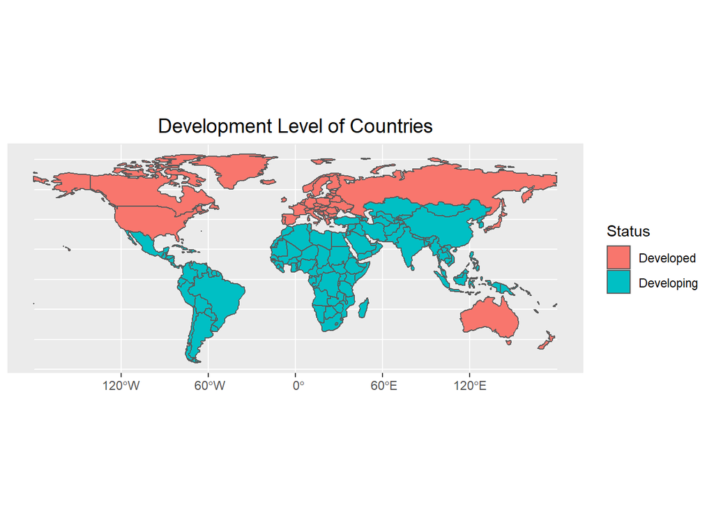

[interactive chart not shown]

[interactive chart not shown]

As we can see on the map; While the stillbirth rate is low in most developed countries, stillbirth rates are high in underdeveloped (developing) countries.

Let’s take a closer look at this data and countries with the highest mortality rates.

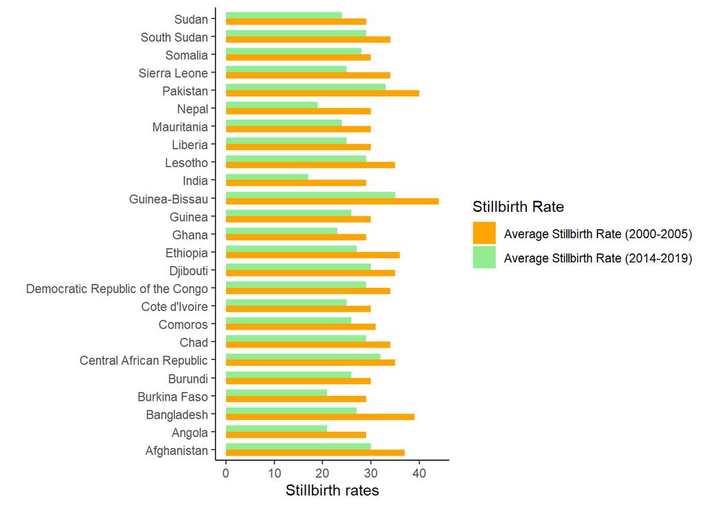

```r
#Importing GDP data
GDP_data <- read_excel("data/imf-dm-export-20210409.xls")
```

```r
#Finding the average GDP of the countries with the highest change in stillbirth rates between 2000-2005 and 2014-2019
GDP_2000_05 <- GDP_data %>%
       slice(1:196) %>%
       select(1,22:27) %>%
       na_if("no data")%>%
       drop_na() %>%
       rename(Country="GDP per capita, current prices
 (U.S. dollars per capita)") %>%
       filter(Country%in%c("Guinea-Bissau","Bangladesh","Nepal"))%>%
       mutate_at(2:7, as.numeric) %>%
       group_by(Country)%>%
       mutate("Average GDP (2000-2005)"=mean(`2000`:`2005`)) %>%
                    select(1,8)
GDP_2014_19 <- GDP_data %>%
       slice(1:196) %>%
       select(1,36:41) %>%
       na_if("no data")%>%
       drop_na() %>%
       rename(Country="GDP per capita, current prices
 (U.S. dollars per capita)") %>%
       filter(Country%in%c("Guinea-Bissau","Bangladesh","Nepal"))%>%
       mutate_at(2:7, as.numeric) %>%
       group_by(Country)%>%
       mutate("Average GDP (2014-2019)"=mean(`2014`:`2019`)) %>%
                    select(1,8)
#View(GDP_2000_05)
#View(GDP_2014_19)
```

```r
GDP_sum <- left_join(GDP_2000_05,GDP_2014_19) %>%
           pivot_longer(!Country, names_to = "Average" , values_to = "GDP")
#View(GDP_sum)
```

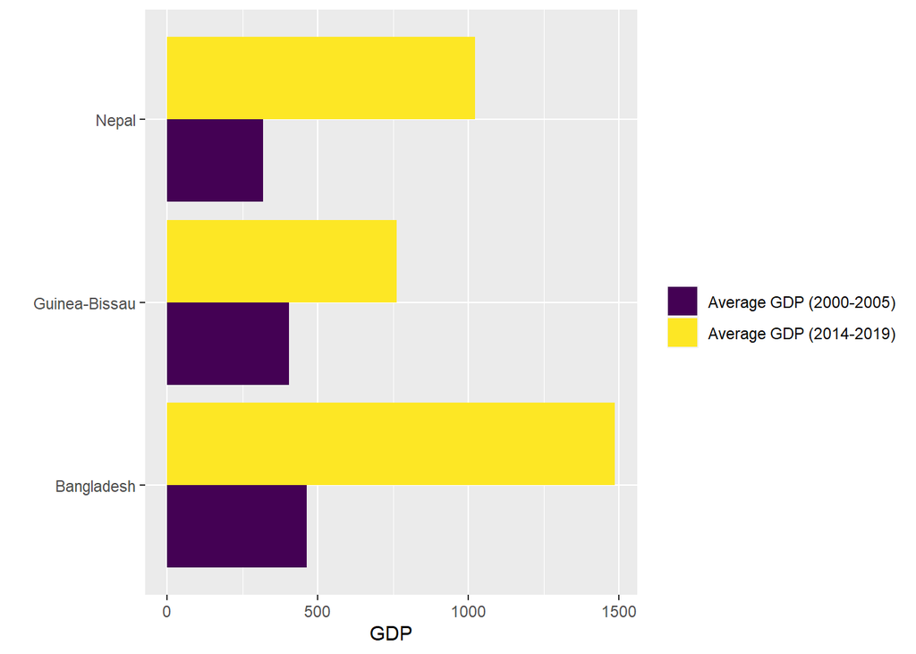

```r
GDP_comp <- GDP_sum%>%
            ggplot( aes(x=GDP, y=Country, fill=Average)) +
            geom_bar(stat="identity", position="dodge") +
            scale_fill_viridis(discrete=TRUE, name="") +
            xlab("GDP")+
            ylab("")
GDP_comp
```

Current health expenditure (CHE) as percentage of gross domestic product (GDP) (%)

```r
CHE_data <- read_csv("data/CHE.csv", skip = 1)
CHE <- CHE_data %>%
       filter(Country%in%c("Guinea-Bissau","Bangladesh","Nepal"))

CHE_2000_05 <- CHE %>%
               select(1,15:20) %>%
               group_by(Country)%>%
               mutate("Average CHE (2000-2005)"=mean(`2000`:`2005`)) %>%
                            select(1,8)
#View(CHE_2000_05)

CHE_2014_18 <- CHE %>%
               select(1,2:6) %>%
               group_by(Country)%>%
               mutate("Average CHE (2014-2018)"=mean(`2014`:`2018`)) %>%
                            select(1,7)
#View(CHE_2014_18)

CHE_sum <- left_join(CHE_2000_05,CHE_2014_18) %>%
           pivot_longer(!Country, names_to = "Average" , values_to = "CHE")
#View(CHE_sum)
```

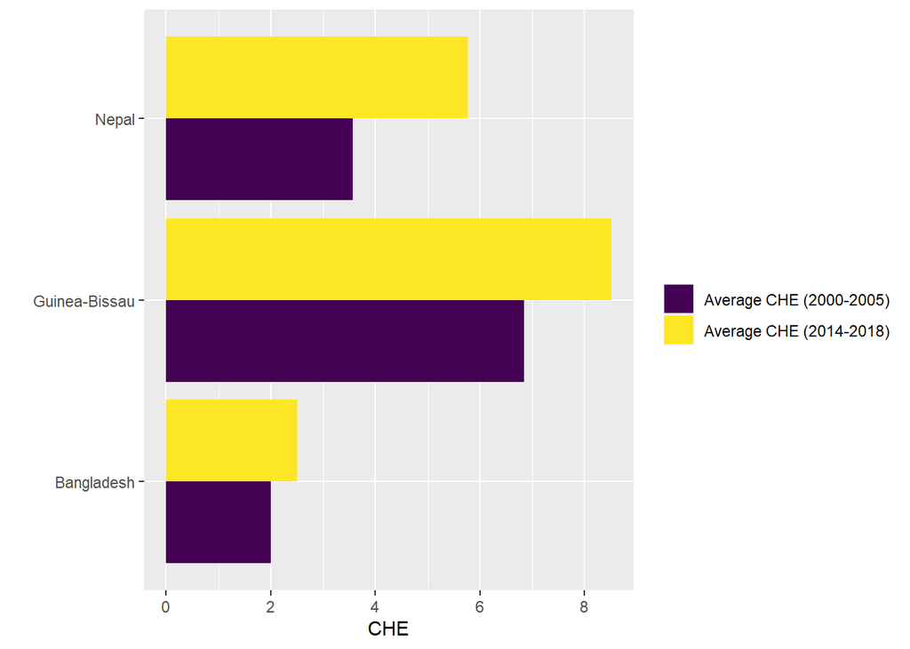

```r
CHE_comp <- CHE_sum%>%
            ggplot( aes(x=CHE, y=Country, fill=Average)) +
            geom_bar(stat="identity", position="dodge") +
            scale_fill_viridis(discrete=TRUE, name="") +
            xlab("CHE")+
            ylab("")
CHE_comp
```

According to WHO, most stillbirths are preventable With quality health care throughout pregnancy and childbirth. To prevent stillbirths, good health and good nutrition before and during pregnancy, quality maternity care and qualified health personnel during birth is necessary. As we can see from the examples above, when countries increase the budget allocated to health services, stillbirth rates decrease.

### Malnutrition

Malnutrition refers to deficiencies or excesses in nutrient intake, an imbalance of essential nutrients.

Malnutrition includes, stunting, underweight, overweight and obesity. Malnutrition can result diet-related non-communicable diseases.

First we will analyze the relation between income groups and malnutrition types such as stunting, overweight and underweight.

```r
#Stunting by Income Levels
Stunting_by_Income_data <- read_csv("data/Stunting-Income.csv")

Stunting_by_Income <- Stunting_by_Income_data %>%
                      rename(Prevalence="Stunting prevalence among children under 5 years of age (%)", IncomeGroup="World Bank income group") %>%
                      separate(Prevalence,c("Prevalence","Interval"),sep=" ") %>%
                      select(1:3)

Stunting_by_Income$Prevalence <- as.numeric(Stunting_by_Income$Prevalence)

Stunting_by_Income <- Stunting_by_Income %>%
                     group_by(IncomeGroup)%>%
                    summarize(`Stunting Prevalence`=mean(Prevalence)) %>%
                    arrange(`Stunting Prevalence`)

Stunting_by_Income$`Stunting Prevalence` <- ceiling(Stunting_by_Income$`Stunting Prevalence`)

View(Stunting_by_Income)
```

```r
#Overweight prevalence by Income Groups.
Overweight_by_Income <- read_csv("data/Overweight-Income.csv")

Overweight_by_Income <- Overweight_by_Income %>%
                        rename(Prevalence="Overweight prevalence among children under 5 years of age (%)", IncomeGroup="World Bank income group") %>%
                        separate(Prevalence,c("Prevalence","Interval"),sep=" ") %>%
                        select(1:3)

Overweight_by_Income$Prevalence <- as.numeric(Overweight_by_Income$Prevalence)

Overweight_by_Income <- Overweight_by_Income %>%
                        group_by(IncomeGroup)%>%
                        summarize(`Overweight Prevalence`=mean(Prevalence))

View(Overweight_by_Income)
```

```r
#Underweight by Income Groups
Underweight_by_Income <- read_csv("data/Underweight-Income.csv")

Underweight_by_Income <- Underweight_by_Income %>%
                        rename(Prevalence="Underweight prevalence among children under 5 years of age (%)", IncomeGroup="World Bank income group") %>%
                        separate(Prevalence,c("Prevalence","Interval"),sep=" ") %>%
                        select(1:3)

Underweight_by_Income$Prevalence <- as.numeric(Underweight_by_Income$Prevalence)

Underweight_by_Income <- Underweight_by_Income %>%
                        group_by(IncomeGroup)%>%
                        summarize(`Underweight Prevalence`=mean(Prevalence))

View(Underweight_by_Income)
```

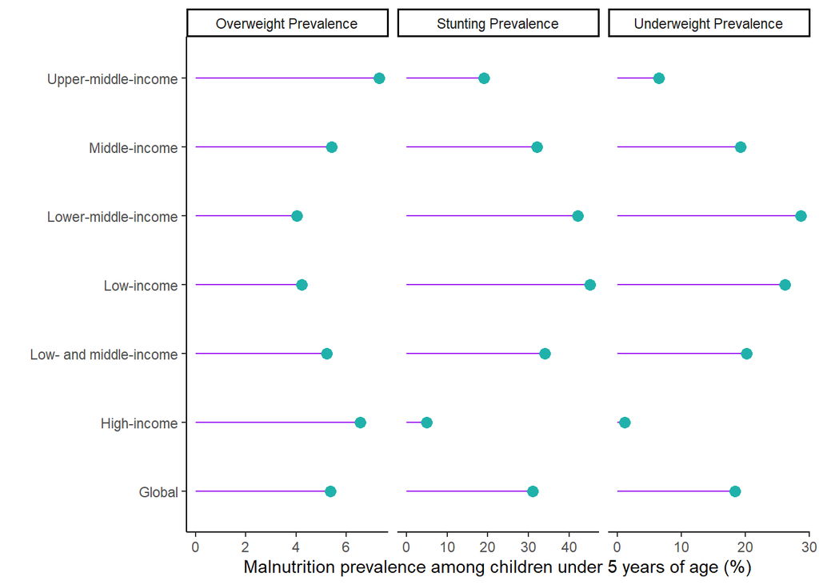

```r
#All of the malnutrition types combined.
Underweight_Overweight <- left_join(Underweight_by_Income, Overweight_by_Income)

Malnutrition_by_Income <- left_join(Underweight_Overweight, Stunting_by_Income)%>%
                          pivot_longer(!IncomeGroup, names_to = "Malnutrition" , values_to = "Prevalence")
View(Malnutrition_by_Income)
```

Stunting rates from 1990 to 2020 by UN regions. We will find the means of the stunting rates.

```r
Stunting_data <- read_csv("data/Stunting.csv")

Stunting <- Stunting_data %>%
            select(1,3)%>%
            rename(Prevalence="Stunting prevalence among children under 5 years of age (%)", Region="UN Region") %>%
            separate(Prevalence,c("Prevalence","Interval"),sep=" ") %>%
            select(1,2)

Stunting$Prevalence <- as.numeric(Stunting$Prevalence)

Stunting <- Stunting %>%
            group_by(Region)%>%
            summarize(Prevalence=mean(Prevalence))
#View(Stunting)
```

UN Regions

```r
UNSD_Methodology <- read_csv("data/UNSD-Methodology.csv") %>% select(4,6,9)

UN_Regions <- UNSD_Methodology[, c(3,2,1)] %>% rename(Country="Country or Area", Region="Sub-region Name", "Main Region"="Region Name")

#View(UN_Regions)
```

Joining UN_Regions data with Stunting data to determine the UN regions for the countries in Stunting.

```r
Stunting_countries <- left_join(UN_Regions, Stunting)
#View(Stunting_countries)
```

```r
#Visualizing the stunting rates.
Stunting_regions_map<- merge(world_new,Stunting_countries, by="Country")
#st_transform(Stunting_regions_map,crs=4326)
#View(Stunting_regions_map)

labels <-  sprintf("<strong>%s</strong><br/> Stunting rate: %s <br/> Region %s", Stunting_regions_map$Region, Stunting_regions_map$`Prevalence`, Stunting_regions_map$`Region`) %>%
            lapply(htmltools::HTML)

pal_col7 <- colorBin(palette="YlOrBr", domain = Stunting_regions_map$`Prevalence`)

Stunting_regions_map %>% leaflet(options = leafletOptions(minZoom = 2, maxZoom = 18)) %>%
                           addPolygons(color="grey",
                                       weight=1,
                                       fillColor = ~pal_col7(`Prevalence`),
                                       fillOpacity = 0.7,
                                       label = labels) %>%
                           addLegend("bottomright",
                                  pal=pal_col7,
                                  values=~`Prevalence`, opacity=1,
                                  title = 'Prevalence')
```

[interactive chart not shown]

Overweight Prevalences by UN regions

```r
Overweight_data <- read_csv("data/Overweight.csv")

Overweight <- Overweight_data %>%
            #  filter(Year=="2019") %>%
              select(1,3) %>%
              rename(Prevalence="Overweight prevalence among children under 5 years of age (%)", Region="UN Region") %>%
              separate(Prevalence,c("Prevalence","Interval"),sep=" ") %>%
              select(1,2)

Overweight$Prevalence <- as.numeric(Overweight$Prevalence)

Overweight <- Overweight %>%
                group_by(Region)%>%
                summarize(Prevalence=mean(Prevalence))
#View(Overweight)
```

```r
Overweight_countries <- left_join(UN_Regions, Overweight)

#View(Overweight_countries)
```

```r
Overweight_regions_map<- merge(world_new,Overweight_countries, by=)
st_transform(Overweight_regions_map,crs=4326)
```

```
## Simple feature collection with 174 features and 4 fields
## Geometry type: MULTIPOLYGON
## Dimension:     XY
## Bounding box:  xmin: -180 ymin: -85.60904 xmax: 180 ymax: 83.64513
## Geodetic CRS:  WGS 84
## First 10 features:
##        Country                          Region Main Region Prevalence
## 1  Afghanistan                   Southern Asia        Asia   2.912903
## 2      Albania                 Southern Europe      Europe   7.380645
## 3      Algeria                 Northern Africa      Africa  11.345161
## 4       Angola              Sub-Saharan Africa      Africa         NA
## 5   Antarctica                            <NA>        <NA>         NA
## 6    Argentina Latin America and the Caribbean    Americas   6.932258
## 7      Armenia                    Western Asia        Asia   7.903226
## 8    Australia       Australia and New Zealand     Oceania  10.574194
## 9      Austria                  Western Europe      Europe   5.138710
## 10  Azerbaijan                    Western Asia        Asia   7.903226
##                          geometry
## 1  MULTIPOLYGON (((61.21082 35...
## 2  MULTIPOLYGON (((20.59025 41...
## 3  MULTIPOLYGON (((11.99951 23...
## 4  MULTIPOLYGON (((16.32653 -5...
## 5  MULTIPOLYGON (((-59.57209 -...
## 6  MULTIPOLYGON (((-65.5 -55.2...
## 7  MULTIPOLYGON (((43.58275 41...
## 8  MULTIPOLYGON (((145.398 -40...
## 9  MULTIPOLYGON (((16.97967 48...
## 10 MULTIPOLYGON (((45.00199 39...
```

```r
#View(Overweight_regions_map)

labels <-  sprintf("<strong>%s</strong><br/> Overweight rate: %s <br/> Region %s", Overweight_regions_map$Country, Overweight_regions_map$`Prevalence`, Overweight_regions_map$`Region`) %>%
            lapply(htmltools::HTML)

pal_col8 <- colorBin(palette="Greens", domain = Overweight_regions_map$`Prevalence`)

Overweight_regions_map %>% leaflet(options = leafletOptions(minZoom = 2, maxZoom = 18)) %>%
                           addPolygons(color="grey",
                                       weight=1,
                                       fillColor = ~pal_col8(`Prevalence`),
                                       fillOpacity = 0.7,
                                       label = labels) %>%
                           addLegend("bottomright",
                                  pal=pal_col8,
                                  values=~`Prevalence`, opacity=1,
                                  title = 'Prevalence')
```

[interactive chart not shown]

Underweight NO EUROPE DATA

```r
Underweight <- read_csv("data/Underweight.csv")

Underweight <- Underweight %>%
               filter(Year=="2020") %>%
               select(1,3) %>%
               rename(Prevalence="Underweight prevalence among children under 5 years of age (%)", Region="UN Region") %>%
               separate(Prevalence,c("Prevalence","Interval"),sep=" ") %>%
               select(1,2)
Underweight$Prevalence <- as.numeric(Underweight$Prevalence)
View(Underweight)
```

```r
Underweight_countries <- left_join(UN_Regions, Underweight)
View(Underweight_countries)
```

```r
Underweight_regions_map<- merge(world_new,Underweight_countries)
st_transform(Underweight_regions_map,crs=4326)
```

```
## Simple feature collection with 174 features and 4 fields
## Geometry type: MULTIPOLYGON
## Dimension:     XY
## Bounding box:  xmin: -180 ymin: -85.60904 xmax: 180 ymax: 83.64513
## Geodetic CRS:  WGS 84
## First 10 features:
##        Country                          Region Main Region Prevalence
## 1  Afghanistan                   Southern Asia        Asia       25.8
## 2      Albania                 Southern Europe      Europe         NA
## 3      Algeria                 Northern Africa      Africa        4.9
## 4       Angola              Sub-Saharan Africa      Africa         NA
## 5   Antarctica                            <NA>        <NA>         NA
## 6    Argentina Latin America and the Caribbean    Americas        2.7
## 7      Armenia                    Western Asia        Asia        3.7
## 8    Australia       Australia and New Zealand     Oceania         NA
## 9      Austria                  Western Europe      Europe         NA
## 10  Azerbaijan                    Western Asia        Asia        3.7
##                          geometry
## 1  MULTIPOLYGON (((61.21082 35...
## 2  MULTIPOLYGON (((20.59025 41...
## 3  MULTIPOLYGON (((11.99951 23...
## 4  MULTIPOLYGON (((16.32653 -5...
## 5  MULTIPOLYGON (((-59.57209 -...
## 6  MULTIPOLYGON (((-65.5 -55.2...
## 7  MULTIPOLYGON (((43.58275 41...
## 8  MULTIPOLYGON (((145.398 -40...
## 9  MULTIPOLYGON (((16.97967 48...
## 10 MULTIPOLYGON (((45.00199 39...
```

```r
#View(Underweight_regions_map)

labels <-  sprintf("<strong>%s</strong><br/> Underweight rate: %s <br/> Region %s", Underweight_regions_map$Country, Underweight_regions_map$`Prevalence`, Underweight_regions_map$`Region`) %>%
            lapply(htmltools::HTML)

palette_col <- colorBin(palette="Spectral", domain = Underweight_regions_map$`Prevalence`)

Underweight_regions_map %>% leaflet(options = leafletOptions(minZoom = 2, maxZoom = 18)) %>%
                           addPolygons(color="grey",
                                       weight=1,
                                       fillColor = ~palette_col(`Prevalence`),
                                       fillOpacity = 0.7,
                                       label = labels) %>%
                           addLegend("bottomright",
                                  pal=palette_col,
                                  values=~`Prevalence`, opacity=1,
                                  title = 'Prevalence')
```

[interactive chart not shown]

### Child mortality rates

According to WHO, in 2019 an estimated 5.2 million children under 5 years died mostly from preventable and treatable causes. The causes of death in children were determined to be preventable and treateble diseases such as diarrhoea and malaria. Such diseases can be prevented or treated with access to simple, affordable interventions including immunization, adequate nutrition, safe water and food and quality care by a trained health provider when needed [2].

Considering this information, we want to analyze the mortality rates of children around the world.

We will first import the infant, under 5 years old and 5 to 14 years old child mortality rates from 2000 to 2019 from UNICEF.

Infant mortality rates:

```r
Infant_mortality_rate <- read_excel("data/Infant-mortality-rate_2020.xlsx",skip = 13)

Infant_mortality <- Infant_mortality_rate %>%
                    filter(`Uncertainty.Bounds*`=="Median") %>%
                    arrange(Country.Name) %>%
                    select(ISO.Code,Country.Name,"2000.5":"2019.5") %>%
                    setNames(c("ISO","Country", 2000:2019, sep=""))
#View(Infant_mortality)
```

Under 5 mortality rates:

```r
Under_five_mortality_rate <- read_excel("data/Under-five-mortality-rate_2020.xlsx", skip = 13)

Under_five_mortality <- Under_five_mortality_rate %>%
                             filter(`Uncertainty.Bounds*`=="Median") %>%
                             arrange(Country.Name) %>%
                             select(ISO.Code,Country.Name,"2000.5":"2019.5") %>%
                             setNames(c("ISO","Country", 2000:2019, sep=""))
#View(Under_five_mortality)
```

5-14 years old child mortality rates:

```r
Mortality_rate_5_to_14 <- read_excel("data/Mortality-rate-among-children-and-you-age-5-to-24_2020.xlsx", sheet = "Age 5to14 Country estimates", skip = 13)

Mortality_5_to_14 <- Mortality_rate_5_to_14 %>%
                          filter(`Uncertainty.Bounds*`=="Median") %>%
                          arrange(Country.Name) %>%
                          select(ISO.Code,Country.Name,"2000.5":"2019.5") %>%
                          setNames(c("ISO","Country", 2000:2019, sep=""))
#View(Mortality_5_to_14)
```

Table of infant, under 5 years old and 5 to 14 years old child mortality rates from 2000 to 2019 and mean of all 3 datasets:

```r
Mortality_rates <- bind_rows(Infant_mortality, Under_five_mortality, Mortality_5_to_14) %>%
                   group_by(Country) %>%
                   summarise_each(funs(mean)) %>%
                   select(-(ISO))
View(Mortality_rates)

Mortality_rates_mean <- Mortality_rates %>%
                  group_by(Country) %>%
                  mutate("Average Mortality Rate"=mean(`2016`:`2019`)) %>%
                  select(1,22)

View(Mortality_rates_mean)
```

We will visualize the average mortality rates data and use the GDP on our map once again to observe the relation with each other.

```r
GDP <- GDP_data %>%
       slice(1:196) %>%
       select(1,22:42) %>%
       na_if("no data")%>%
       drop_na() %>%
       rename(Country="GDP per capita, current prices
 (U.S. dollars per capita)")
GDP <- GDP %>%
       mutate_at(2:22, as.numeric)
```

```r
GDP_mean <- GDP %>%
            group_by(Country) %>%
            mutate("Average GDP"=mean(`2016`:`2019`)) %>%
            select(1,23)
View(GDP_mean)
```

```r
Mortality_GDP <- left_join(Mortality_rates_mean, GDP_mean)
View(Mortality_GDP)
```

```r
Mortality_map <- merge(world_new, Mortality_GDP, by="Country")
#st_transform(Mortality_map,crs=4326)
#View(Mortality_map)

labels <-  sprintf("<strong>%s</strong><br/> Mortality rates: %s<br/> GDP: %s", Mortality_map$Country, Mortality_map$`Average Mortality Rate`, Mortality_map$`Average GDP`) %>%
            lapply(htmltools::HTML)

pal_col2 <- colorBin(palette="YlOrRd", domain = Mortality_map$`Average Mortality Rate`)

Mortality_map %>% leaflet(options = leafletOptions(minZoom = 2, maxZoom = 18)) %>%
                           addPolygons(color="grey",
                                       weight=1,
                                       fillColor = ~pal_col2(`Average Mortality Rate`),
                                       fillOpacity = 0.7,
                                       label = labels) %>%
                           addLegend("bottomright",
                                  pal=pal_col2,
                                  values=~`Average Mortality Rate`, opacity=1,
                                  title = 'Mortality Rates') %>%
                           addTiles()
```

[interactive chart not shown]

Access to drinking water

NOTE: According to UNICEF and WHO, Basic Water: Drinking water from an improved source, provided collection time is not more than 30 minutes for a roundtrip including queuing. Unimproved: Drinking water from an unprotected dug well or unprotected spring.

We will use the “Basic” data from the “National” section.

```r
Water_Access <- read_excel("data/WASH-data-tables.xlsx", sheet = "Water", skip=2)
Water_Access <- Water_Access %>%
                select(1,2,5) %>%
                rename(Country="...1", Year="...2", "Basic Water Access"="At least basic...5") %>%
                mutate(`Basic Water Access`=case_when(`Basic Water Access`==">99"~"99", TRUE~`Basic Water Access`))%>%
                filter(Year=="2017") %>%
                select(1,3)

Water_Access$`Basic Water Access` <- as.numeric(Water_Access$`Basic Water Access`) %>%
                                     ceiling()

View(Water_Access)
```

```r
Water_Access_map <- merge(world_new,Water_Access, by="Country")
st_transform(Water_Access_map,crs=4326)
```

```
## Simple feature collection with 171 features and 2 fields
## Geometry type: MULTIPOLYGON
## Dimension:     XY
## Bounding box:  xmin: -180 ymin: -55.61183 xmax: 180 ymax: 83.64513
## Geodetic CRS:  WGS 84
## First 10 features:
##        Country Basic Water Access                       geometry
## 1  Afghanistan                 68 MULTIPOLYGON (((61.21082 35...
## 2      Albania                 92 MULTIPOLYGON (((20.59025 41...
## 3      Algeria                 94 MULTIPOLYGON (((11.99951 23...
## 4       Angola                 56 MULTIPOLYGON (((16.32653 -5...
## 5    Argentina                 NA MULTIPOLYGON (((-65.5 -55.2...
## 6      Armenia                 99 MULTIPOLYGON (((43.58275 41...
## 7    Australia                 99 MULTIPOLYGON (((145.398 -40...
## 8      Austria                 99 MULTIPOLYGON (((16.97967 48...
## 9   Azerbaijan                 92 MULTIPOLYGON (((45.00199 39...
## 10     Bahamas                 99 MULTIPOLYGON (((-77.53466 2...
```

```r
View(Water_Access_map)

labels <-  sprintf("<strong>%s</strong><br/> Basic Water Access: %s ", Water_Access_map$Country, Water_Access_map$`Basic Water Access`) %>%
            lapply(htmltools::HTML)

pal_col3 <- colorBin(palette="viridis", domain = Water_Access_map$`Basic Water Access`)

Water_Access_map %>% leaflet(options = leafletOptions(minZoom = 0, maxZoom = 18)) %>%
                           addPolygons(color="grey",
                                       weight=1,
                                       fillColor = ~pal_col3(`Basic Water Access`),
                                       fillOpacity = 0.7,
                                       label = labels) %>%
                           addLegend("bottomright",
                                  pal=pal_col3,
                                  values=~`Basic Water Access`, opacity=1,
                                  title = 'Basic Water Access')
```

[interactive chart not shown]

Sanitation

```r
Sanitation <- read_excel("data/WASH-data-tables.xlsx", sheet = "Sanitation", skip=2)

Sanitation <- Sanitation %>%
                select(1,2,5) %>%
                rename(Country="...1", Year="...2", "Basic Sanitation"="At least basic...5") %>%
                mutate(`Basic Sanitation`=case_when(`Basic Sanitation`==">99"~"99", TRUE~`Basic Sanitation`))%>%
                filter(Year=="2017") %>%
                select(1,3)

Sanitation$`Basic Sanitation` <- as.numeric(Sanitation$`Basic Sanitation`) %>%
                                 ceiling()

View(Sanitation)
```

```r
Sanitation_map <- merge(world_new,Sanitation, by="Country")
st_transform(Sanitation_map,crs=4326)
```

```
## Simple feature collection with 171 features and 2 fields
## Geometry type: MULTIPOLYGON
## Dimension:     XY
## Bounding box:  xmin: -180 ymin: -55.61183 xmax: 180 ymax: 83.64513
## Geodetic CRS:  WGS 84
## First 10 features:
##        Country Basic Sanitation                       geometry
## 1  Afghanistan               44 MULTIPOLYGON (((61.21082 35...
## 2      Albania               98 MULTIPOLYGON (((20.59025 41...
## 3      Algeria               88 MULTIPOLYGON (((11.99951 23...
## 4       Angola               50 MULTIPOLYGON (((16.32653 -5...
## 5    Argentina               NA MULTIPOLYGON (((-65.5 -55.2...
## 6      Armenia               94 MULTIPOLYGON (((43.58275 41...
## 7    Australia               99 MULTIPOLYGON (((145.398 -40...
## 8      Austria               99 MULTIPOLYGON (((16.97967 48...
## 9   Azerbaijan               93 MULTIPOLYGON (((45.00199 39...
## 10     Bahamas               95 MULTIPOLYGON (((-77.53466 2...
```

```r
View(Sanitation_map)

labels <-  sprintf("<strong>%s</strong><br/> Sanitation: %s ", Sanitation_map$Country, Sanitation_map$`Basic Sanitation`) %>%
            lapply(htmltools::HTML)

pal_col4<- colorBin(palette="viridis", domain = Sanitation_map$`Basic Sanitation`)

Sanitation_map %>% leaflet(options = leafletOptions(minZoom = 0, maxZoom = 18)) %>%
                           addPolygons(color="grey",
                                       weight=1,
                                       fillColor = ~pal_col4(`Basic Sanitation`),
                                       fillOpacity = 0.7,
                                       label = labels) %>%
                           addLegend("bottomright",
                                  pal=pal_col4,
                                  values=~`Basic Sanitation`, opacity=1,
                                  title = 'Basic Sanitation')
```

[interactive chart not shown]

Hygiene

```r
Hygiene <- read_excel("data/WASH-data-tables.xlsx", sheet = "Hygiene", skip=1)

Hygiene <- Hygiene %>%
                select(1,2,5) %>%
                rename(Country="COUNTRY, AREA OR TERRITORY", Year="...2", "Basic Hygiene"="Basic...5") %>%
                filter(Year=="2017") %>%
                select(1,3)

Hygiene$`Basic Hygiene` <- as.numeric(Hygiene$`Basic Hygiene`) %>%
                           ceiling()


#View(Hygiene)
```

```r
Hygiene_map <- merge(world_new,Hygiene, by="Country")
st_transform(Hygiene_map,crs=4326)
```

```
## Simple feature collection with 74 features and 2 fields
## Geometry type: MULTIPOLYGON
## Dimension:     XY
## Bounding box:  xmin: -117.1278 ymin: -34.81917 xmax: 167.8449 ymax: 55.38525
## Geodetic CRS:  WGS 84
## First 10 features:
##                             Country Basic Hygiene
## 1                       Afghanistan            38
## 2                           Algeria            84
## 3                            Angola            27
## 4                           Armenia            95
## 5                        Azerbaijan            84
## 6                        Bangladesh            35
## 7                            Belize            91
## 8                             Benin            12
## 9  Bolivia (Plurinational State of)            26
## 10                     Burkina Faso            12
##                          geometry
## 1  MULTIPOLYGON (((61.21082 35...
## 2  MULTIPOLYGON (((11.99951 23...
## 3  MULTIPOLYGON (((16.32653 -5...
## 4  MULTIPOLYGON (((43.58275 41...
## 5  MULTIPOLYGON (((45.00199 39...
## 6  MULTIPOLYGON (((92.67272 22...
## 7  MULTIPOLYGON (((-89.14308 1...
## 8  MULTIPOLYGON (((2.691702 6....
## 9  MULTIPOLYGON (((-62.84647 -...
## 10 MULTIPOLYGON (((-2.827496 9...
```

```r
#View(Hygiene_map)

labels <-  sprintf("<strong>%s</strong><br/> Sanitation: %s ", Hygiene_map$Country, Hygiene_map$`Basic Hygiene`) %>%
            lapply(htmltools::HTML)

pal_col5 <- colorBin(palette="viridis", domain = Hygiene_map$`Basic Hygiene`)

Hygiene_map %>% leaflet(options = leafletOptions(minZoom = 0, maxZoom = 18)) %>%
                           addPolygons(color="grey",
                                       weight=1,
                                       fillColor = ~pal_col5(`Basic Hygiene`),
                                       fillOpacity = 0.7,
                                       label = labels) %>%
                           addLegend("bottomright",
                                  pal=pal_col5,
                                  values=~`Basic Hygiene`, opacity=1,
                                  title = 'Basic Hygiene')
```

[interactive chart not shown]

Death by diarrhoeal diseases in the year of 2017 (Deaths per 1000 live births)

```r
Death_by_diarrhoeal_diseases <- read_csv("data/Death_by_diarrhoeal_diseases.csv", skip = 3)

Death_by_diarrhoeal_diseases <- Death_by_diarrhoeal_diseases %>%
                                select(1,4)

View(Death_by_diarrhoeal_diseases)
```

```r
Diarrhoea_Water <- left_join(Death_by_diarrhoeal_diseases,Water_Access)

Diarrhoea_Sanitation <- left_join(Death_by_diarrhoeal_diseases,Sanitation) %>%
                        select("Basic Sanitation")

Diarrhoea_Hygiene <- left_join(Death_by_diarrhoeal_diseases,Hygiene) %>%
                     select("Basic Hygiene")

Diarrhoea_WASH <- bind_cols(Diarrhoea_Water, Diarrhoea_Sanitation, Diarrhoea_Hygiene)

View(Diarrhoea_WASH)
```

```r
Death_by_DD_map <- merge(world_new,Diarrhoea_WASH, by="Country")
st_transform(Death_by_DD_map,crs=4326)
```

```
## Simple feature collection with 165 features and 5 fields
## Geometry type: MULTIPOLYGON
## Dimension:     XY
## Bounding box:  xmin: -180 ymin: -55.61183 xmax: 180 ymax: 83.23324
## Geodetic CRS:  WGS 84
## First 10 features:
##        Country 0-4 years Basic Water Access Basic Sanitation Basic Hygiene
## 1  Afghanistan       5.2                 68               44            38
## 2      Albania       0.1                 92               98            NA
## 3      Algeria       1.2                 94               88            84
## 4       Angola       7.2                 56               50            27
## 5    Argentina       0.1                 NA               NA            NA
## 6      Armenia       0.2                 99               94            95
## 7    Australia       0.0                 99               99            NA
## 8      Austria       0.0                 99               99            NA
## 9   Azerbaijan       1.6                 92               93            84
## 10     Bahamas       0.2                 99               95            NA
##                          geometry
## 1  MULTIPOLYGON (((61.21082 35...
## 2  MULTIPOLYGON (((20.59025 41...
## 3  MULTIPOLYGON (((11.99951 23...
## 4  MULTIPOLYGON (((16.32653 -5...
## 5  MULTIPOLYGON (((-65.5 -55.2...
## 6  MULTIPOLYGON (((43.58275 41...
## 7  MULTIPOLYGON (((145.398 -40...
## 8  MULTIPOLYGON (((16.97967 48...
## 9  MULTIPOLYGON (((45.00199 39...
## 10 MULTIPOLYGON (((-77.53466 2...
```

```r
#View(Death_by_DD_map)

labels <-  sprintf("<strong>%s</strong><br/> Death rate: %s <br/> Water rate: %s <br/> sanitation rate: %s <br/> hygiene rate: %s ", Death_by_DD_map$Country, Death_by_DD_map$`0-4 years`, Death_by_DD_map$`Basic Water Access`,Death_by_DD_map$`Basic Sanitation`,Death_by_DD_map$`Basic Hygiene`) %>%
            lapply(htmltools::HTML)

pal_col6 <- colorBin(palette="viridis", domain = Death_by_DD_map$`0-4 years`)

Death_by_DD_map %>% leaflet(options = leafletOptions(minZoom = 0, maxZoom = 18)) %>%
                           addPolygons(color="grey",
                                       weight=1,
                                       fillColor = ~(pal_col6(`0-4 years`)),
                                       fillOpacity = 0.7,
                                       label = labels) %>%
                           addLegend("bottomright",
                                  pal=(pal_col6),
                                  values=~`0-4 years`, opacity=1,
                                  title = '0-4 years')
```

[interactive chart not shown]

Deaths by Malaria in 2017 (Deaths per 1000 live births)

```r
Death_by_malaria <- read_csv("data/Death_by_malaria.csv", skip = 3)

Death_by_malaria <- Death_by_malaria %>%
                                select(1,4)
View(Death_by_malaria)
```

```r
Malaria_Water <- left_join(Death_by_malaria,Water_Access)

Malaria_Sanitation <- left_join(Death_by_malaria,Sanitation) %>%
                        select("Basic Sanitation")

Malaria_Hygiene <- left_join(Death_by_malaria,Hygiene) %>%
                     select("Basic Hygiene")

Malaria_WASH <- bind_cols(Malaria_Water, Malaria_Sanitation, Malaria_Hygiene)

View(Malaria_WASH)
```

```r
Death_by_malaria_map <- merge(world_new,Malaria_WASH, by="Country")
st_transform(Death_by_malaria_map,crs=4326)
```

```
## Simple feature collection with 165 features and 5 fields
## Geometry type: MULTIPOLYGON
## Dimension:     XY
## Bounding box:  xmin: -180 ymin: -55.61183 xmax: 180 ymax: 83.23324
## Geodetic CRS:  WGS 84
## First 10 features:
##        Country 0-4 years Basic Water Access Basic Sanitation Basic Hygiene
## 1  Afghanistan       0.1                 68               44            38
## 2      Albania       0.0                 92               98            NA
## 3      Algeria       0.0                 94               88            84
## 4       Angola       5.4                 56               50            27
## 5    Argentina       0.0                 NA               NA            NA
## 6      Armenia       0.0                 99               94            95
## 7    Australia       0.0                 99               99            NA
## 8      Austria       0.0                 99               99            NA
## 9   Azerbaijan       0.0                 92               93            84
## 10     Bahamas       0.0                 99               95            NA
##                          geometry
## 1  MULTIPOLYGON (((61.21082 35...
## 2  MULTIPOLYGON (((20.59025 41...
## 3  MULTIPOLYGON (((11.99951 23...
## 4  MULTIPOLYGON (((16.32653 -5...
## 5  MULTIPOLYGON (((-65.5 -55.2...
## 6  MULTIPOLYGON (((43.58275 41...
## 7  MULTIPOLYGON (((145.398 -40...
## 8  MULTIPOLYGON (((16.97967 48...
## 9  MULTIPOLYGON (((45.00199 39...
## 10 MULTIPOLYGON (((-77.53466 2...
```

```r
View(Death_by_malaria_map)

labels <-  sprintf("<strong>%s</strong><br/> Death rate: %s <br/> Water rate: %s <br/> sanitation rate: %s <br/> hygiene rate: %s ", Death_by_malaria_map$Country, Death_by_malaria_map$`0-4 years`, Death_by_malaria_map$`Basic Water Access`,Death_by_malaria_map$`Basic Sanitation`,Death_by_malaria_map$`Basic Hygiene`) %>%
            lapply(htmltools::HTML)

pal_col7 <- colorBin(palette="viridis", domain = Death_by_DD_map$`0-4 years`)

Death_by_malaria_map %>% leaflet(options = leafletOptions(minZoom = 0, maxZoom = 18)) %>%
                           addPolygons(color="grey",
                                       weight=1,
                                       fillColor = ~pal_col7(`0-4 years`),
                                       fillOpacity = 0.7,
                                       label = labels) %>%
                           addLegend("bottomright",
                                  pal=pal_col6,
                                  values=~`0-4 years`, opacity=1,
                                  title = '0-4 years')
```

[interactive chart not shown]